#### 1.4 Colonization-Extinction equilibrium

In our previous example populations could grow without problems or risks. However, often disaster can strike, wiping out a complete populations. If no lasting damage was done to the habitat, nearby populations could afterwards recolonize the empty patch. But migration needs to be frequent enough for the metapopulation to persist. In this section we will look at the interplay between extinction and recolonization by migration. Understanding what level of disturbance a species can still tolerate without going extinct is very important for successful conservation strategies.  
We will stay in the same scenario as before, studying the colonization of the Hawaiian Islands. However, to add a level of complexity, we will not study actively migrating humans, but instead think about a passive disperser, such as a small insect. It is dependent on the prevailing winds and ocean currents (going east-west around Hawaii) for its migration. For our current scenario we would therefore need a sort of asymmetrical stepping-stone dispersal model, allowing migration in mainly one direction (west). qN does not provide such a ready-made scenario. However, it does allow us to define a different dispersal rate from each patch to each other patch. Instead of a single dispersal rate value, we will provide qN with a matrix of values, containing the specific dispersal rate from each patch to each patch. Have a look at the setup file below.  
> # Finding a colonization-extinction equilibrium > generations 1000 > patch_number 6 > dispersal_rate {{0.9946 0.0050 0.0001 0.0001 0.0001 0.0001} > {0.0001 0.9946 0.0050 0.0001 0.0001 0.0001} > {0.0001 0.0001 0.9946 0.0050 0.0001 0.0001} > {0.0001 0.0001 0.0001 0.9946 0.0050 0.0001} > {0.0001 0.0001 0.0001 0.0001 0.9946 0.0050} > {0.0001 0.0001 0.0001 0.0001 0.0001 0.9995}} > patch_capacity 500 > patch_ini_size {4 rep(0,5)}mating_system 3 # 3 = dioecious random mating; 0 = hermaphrodite random mating (default) > mating_nb_offspring_model 6 # 6 = logistic growth > growth_rate 0.5 > regulation_model_adults 1 # 1= yes, 0 = no regulation > extinction_rate 0.01 > stat {adlt.nbPops adlt.nbInd emigrants adlt.nbInd_p} > replicates 20 > folder demography/colonisation2 > seed 42

The matrix can almost be considered a vector of vectors (indicated by the {}). Each row contains the dispersal rates of a single patch to all the patches in the model. The first value of the matrix therefore specifies the probability of individuals of patch 1 that will ‘disperse’ to patch 1 (i.e. stay where they are). The second value indicates the probability of individuals of patch 1 that will disperse to patch 2. The third value from the top row is the dispersal rate from patch 1 to patch 3 etc. etc. Two things should be noted though. First the diagonal of the matrix is the probability that an individual will stay in its patch. Secondly, because total probability should be unity, each row should sum up to one. (Question: why is this not true for each column?) From our current dispersal rate matrix we can read that the large majority of individuals will stay in their current patch (the high values in the diagonal). The value right behind the diagonal (0.005) is the probability to disperse to the next patch and corresponds with our dispersal rate value from the previous example. However, this value is only behind the diagonal, not in front of it. This makes dispersal asymmetric in our current scenario: the probability to migrate to the next patch (the island to the west) is much higher than to the previous patch (the island to the east), symbolising the prevailing ocean currents. However, we see that dispersal to any of the other patches is not null. A tiny probability exists for an insect, either as an adult or as an egg, to end up on any of the other islands, e.g. by animal transportation.

The remainder of the setup file is based on the colonisation.ini file with some slight modifications. By now you should be able to see and understand most adjustments yourself. The big addition compared to the last section is the introduction of extinction_rate. This gives the probability per patch per generation of going extinct i.e. all individuals will be removed from that patch symbolising an epidemic outbreak or volcano eruption.

The other big difference is the addition of replicates and seed. As with real world experiments, it is always a good idea to repeat an experiment multiple times to see if a particular outcome is robust. This is especially true for any simulation with a lot of stochasticity. The previous simulation already had stochasticity introduced in the form of dispersal probability. The current model, however, will be much more sensitive through the probability of extinction of a complete subpopulation. This could change the outcome of the simulation so heavily, that it is advisable to perform multiple replicates.

Question: Generally in science, when comparing findings, one wants to know if these are ‘significant’ by using some statistical test or other. When using computer simulations, statistical tests are hardly ever used. Why do you think that is so?

The last parameter seed is also linked to the stochasticity of the simulation. Ironically enough, a computer has a hard time producing random numbers. It always needs some input to transmutate into something ‘random’. Normally a program will use the current data-time to transmogrify, but you can also provide it with a ‘seed’ from which it will start producing random numbers. Once it has its first random number produced, it can use that to produce consecutive random numbers. Seed allows us to reuse exactly the same stochasticity. This is practical when you would like to reproduce a specific outcome you once found, or when different people need to have exactly the same stochastic outcome. Hence by defining the seed at 42 we will now make sure that you will get the same outcome as shown in this tutorial. Question: Why are your model outcomes exactly the same when you run a setup file twice with the same seed, but not when you run two replicates within one setup file using seed?

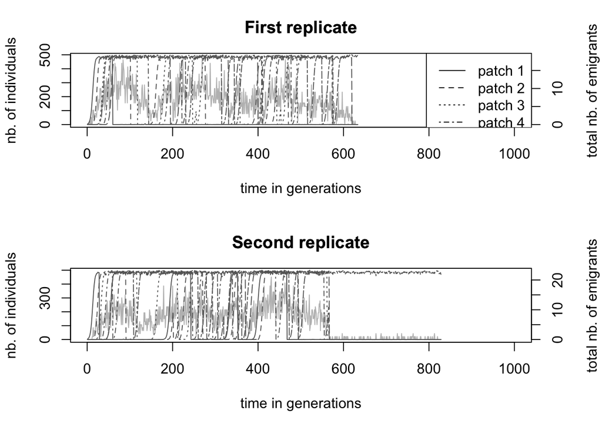

```r
    # Select the simulation_stats.txt file from the extinction simulation
    extinct<-read.table("demography/colonisation2/simulation_stats.txt", header=T)
    # extract the data of replicate 1 and 2
    rep1<-extinct[extinct$replicate==1,]
    rep2<-extinct[extinct$replicate==2,]

        # define a function to plot the data (saves typing)
        plot.extinction<-function(mat, tit=""){
            par(mar=c(5,4,3,4)+0.1)
            total.migrants<-mat$emigrants * mat$adlt.nbPops
            plot(mat$generation, total.migrants, type="l", main=tit,lwd=1, col="grey", axes=FALSE, xlab="", ylab="")
            axis(4)
            par(new=TRUE)
            plot(mat$generation,mat$adlt.nbInd_p1,main=tit, type="l",lty=1, col="grey40", xlab="time in generations", ylab="nb. of individuals")
            for(i in 2:6) lines(mat$generation, mat[,5+i], lty=i, col="grey40")

            #plot(mat$generation,mat$colonisers, axes=FALSE, xlab="", ylab="", ylim=c(0,10))
            #points(mat$generation,mat$emigrants,pch=4)
            mtext("total nb. of emigrants",side=4, line=3)
            #for(i in 2:6) points(mat$generation, mat[,5+i], cex=0.7, pch=as.character(i), lty=1+i, col="grey40")
        }

    # plot the data of replicate 1 and 2
    par(mfrow=c(2,1))
    plot.extinction(rep1, tit="First replicate")
    legend("topright", paste("patch",1:6), lty=1:6)
    plot.extinction(rep2, tit="Second replicate")
```

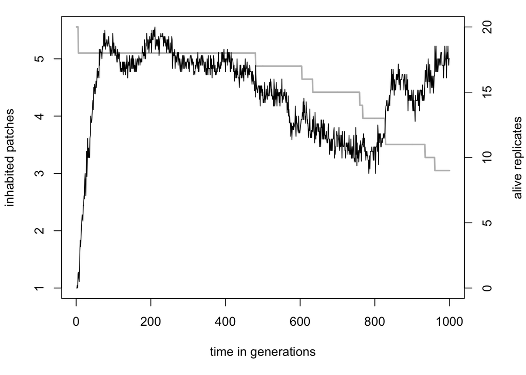

```r
    # select the simulation_mean.txt file
    mean.ext<-read.table("demography/colonisation2/simulation_mean.txt", h=T)
    # plotting the number of inhabited patches and alive replicates across time
    par(mar=c(5,4,1,4)+0.1, mfrow=c(1,1))
    plot(mean.ext$generation, mean.ext$alive.rpl,ylim=c(0,20), type="l",lty=1, lwd=2,col="grey", xlab="time in generations", ylab="", axes=FALSE)
    axis(4)
    mtext("alive replicates", side=4, line=3)
    par(new=TRUE)
    plot(mean.ext$generation, mean.ext$adlt.nbPops, type="l", lty=1, lwd=1, xlab="", ylab="inhabited patches")
```

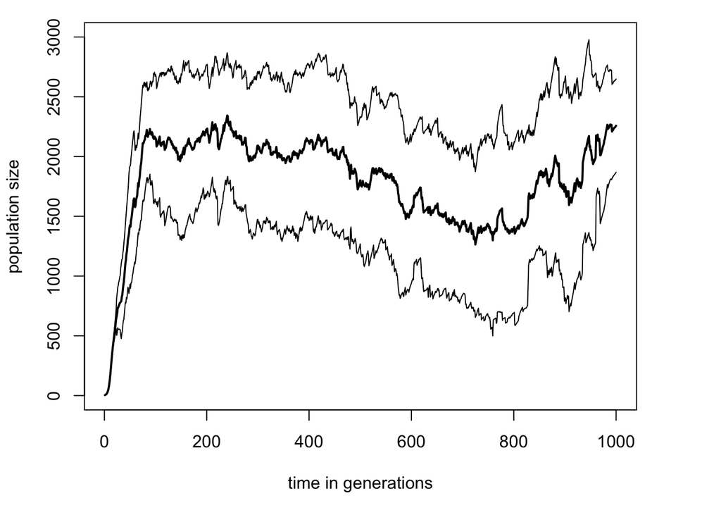

```r
    # select the simulation_var.txt file
    var.ext<-read.table("demography/colonisation2/simulation_var.txt", h=T)
    # plotting
    plot(mean.ext$generation, mean.ext$adlt.nbInd, ylim=c(0,3000),type="l",lty=1, lwd=2, xlab="time in generations", ylab="population size")
    lines(mean.ext$generation, I(mean.ext$adlt.nbInd+sqrt(var.ext$adlt.nbInd)))
    lines(mean.ext$generation, I(mean.ext$adlt.nbInd-sqrt(var.ext$adlt.nbInd)))
```

What we can conclude from this is that extinction seems to be a dichotomous process in our simulations. Either the population is healthy with many individuals across several patches, or the population is completely extinct. But across replicates we do not see any obvious pattern of steady decline to extinction. The power of such a simulation model is that we could now start studying the influence certain parameters have on the behaviour of such populations? How does the carrying capacity influence extinction risk? How strong is the effect of fecundity? Are hermaphrodites less sensitive to extinction than dioecious species? By varying certain parameters and rerunning the simulation in many replicates, we can create predictions of population demographic behaviour, something which would be very difficult to do in vivo. Question: Rerun the extinction.ini setup file with a different value for seed and reproduce the graphs above. Do they look very different from the ones above? Which ones have changed less with the changing of the seed and which ones more? Why? What if you would run your setup file twice with different seeds, but with a 1000 replicates. Which graphs do you expect to be very similar and which ones still very different between the two runs?